# Fitting spatial and spatiotemporal models

## What we’ve learned so far

- Time series can be useful for identifying structure, improving precision, and accuracy of forecasts
- Modeling multivariate time series
  - e.g. MARSS() function, with each observed time series mapped to a single discrete state
- Using DFA
  - Structure determined by factor loadings

## Response generally the same variable (not separate species)

- Making inference about population as a whole involves jointly modeling both time series

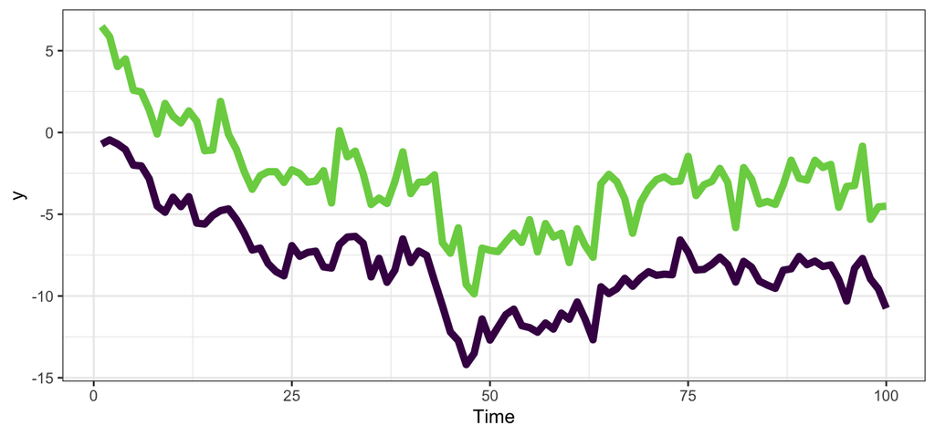

## Lots of time series -> complicated covariance matrices

- For unconstrained covariance matrices, the number of covariance matrix parameters = \(m*(m+1)/2\)
  - problematic for m > 5 or so
- MARSS solutions: diagonal matrices or ‘equalvarcov’
- DFA runs into same issues with estimating unconstrained \(R\) matrix

## Potential problems with both the MARSS and DFA approach

- Sites separated by large distances may be grouped together
- Sites close to one another may be found to have very different dynamics

## Switching gears: spatial models

- Data often have spatial attributes
- Ideal world:
  - Plug spatial covariates into a GLM / GLMM
  - Residuals are uncorrelated

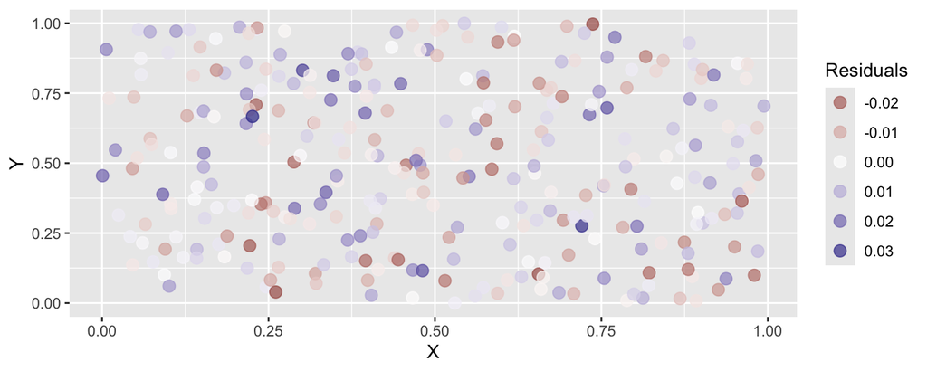

## Reality

- Residual spatial autocorrelation

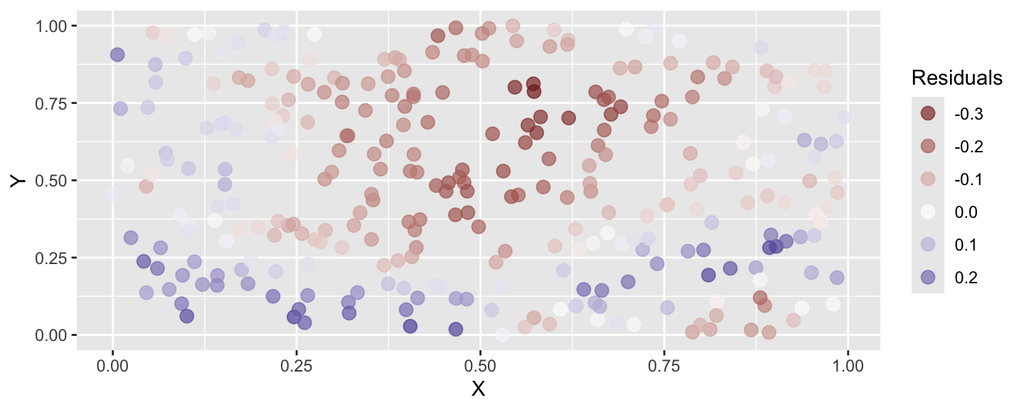

## Modeling spatial autocorrelation

- Need ‘wiggly’/smooth surface for approximating all spatial variables missing from model (‘latent’ variables)
- Several approaches exist
  - 2D smooths in mgcv
  - Random fields and the Stochastic Partial Differential Equation (SPDE)
  - Nearest neighbor methods

## Spatial smoothing with GAMs (mgcv)

```r
gam(y ~ s(lon, lat) + s(time), ...)

gam(y ~ s(lon, lat) + s(time) +
      ti(lon, lat, time, d=c(2,1)), ...)

gam(y ~ s(lon, lat, by = "time") +
      s(time), ...)
```

## Spatial smoothing with SPDE (INLA, inlabru)

- SPDE differs in that it explicitly estimates meaningful parameters for spatial covariance function
- SPDE and GAMs can produce the identical results
- Miller, D.L., Glennie, R. & Seaton, A.E. Understanding the Stochastic Partial Differential Equation Approach to Smoothing. JABES 25, 1–16 (2020)

## Matérn covariance

Flexible, can be exponential or Gaussian shape

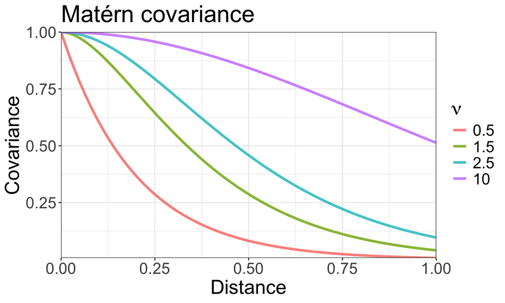

## Predictive process models

- Estimate spatial field as random effects
- High dimensional datasets computationally challenging
- Gaussian process predictive process models:
  - Estimate values at a subset of locations in the time series
  - ‘knots’, ‘vertices’, or ‘control points’
  - Use covariance function to interpolate from knots to locations of observations

## Predictive process models

- More knots (vertical dashed lines) = more wiggliness & parameters to estimate

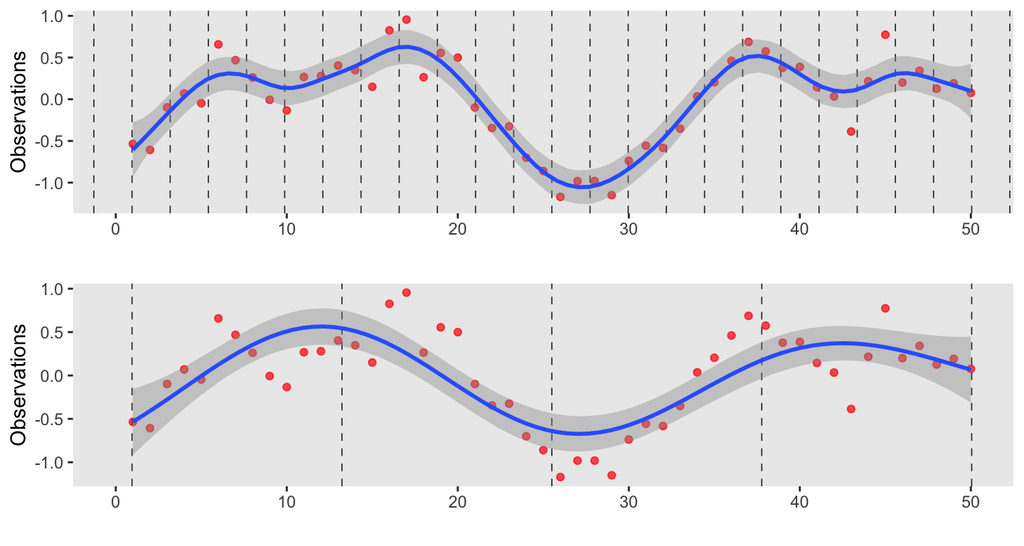

## Spatial data types

- Lattice: gridded data, e.g. interpolated SST from satellite observations

–

- Areal: data collected in neighboring spatial areas, e.g. commercial catch records by state / county

–

- Georeferenced: data where observations are associated with latitude and longitude
  - Locations may be unique or repeated (stations)

## Why is space important?

- Data covary spatially (data that are closer are more similar)
- Relationship between distance and covariance can be described with a spatial covariance function
- Covariance function in 2D may be
  - isotropic (same covariance in each direction)
  - anisotropic (different in each direction)

## What is a random field?

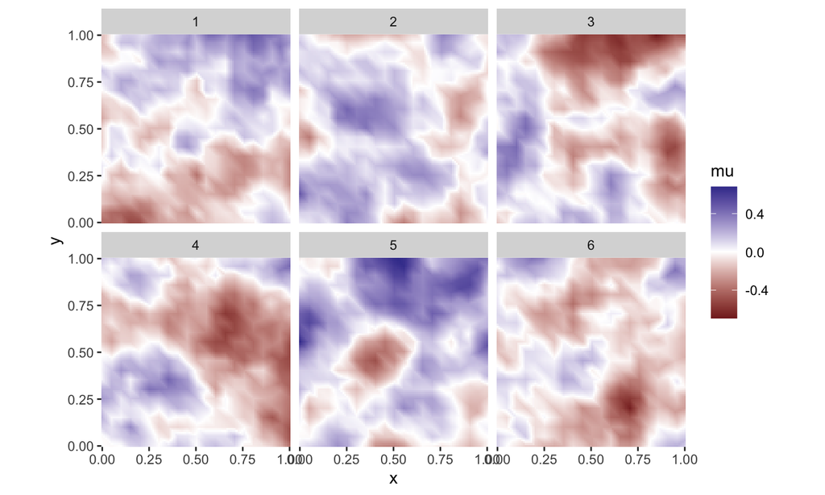

## Random field

- A 2 dimensional “Gaussian Process”
- A realization from a multivariate normal distribution with some covariance function

## Random field

- A way of estimating a wiggly surface to account for spatial and/or spatiotemporal correlation in data.
- Alternatively, a way of estimating a wiggly surface to account for “latent” or unobserved variables.
- As a bonus, it provides useful covariance parameter estimates: spatial variance and the distance at data points are effectively uncorrelated (“range”)

## Many ways to simulate random fields

- `RandomFields::RFsimulate()` simulates univariate / multivariate fields
- `fields::sim.rf()` simulates random fields on a grid
- `geoR::grf()` simulates random fields with irregular observations
- `glmmfields::sim_glmmfields()` simulates random fields with/without extreme values
- `sdmTMB::sdmTMB_simulate()` simulates univariate fields with `sdmTMB`

??? Homework: try to work through some of these yourself. Make some plots, and see how changing the covariance affects the smoothness of these fields.

## Effects of changing variance and range

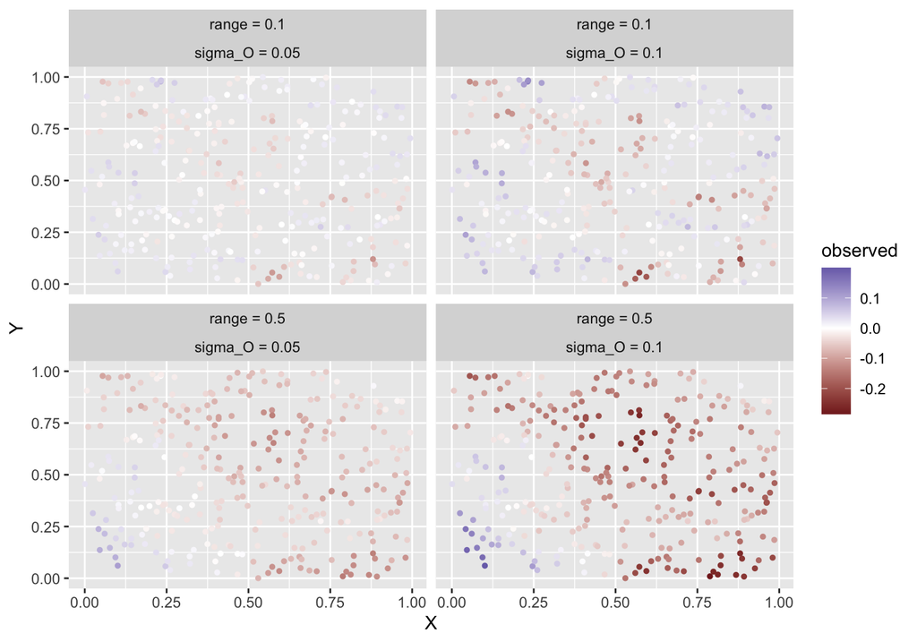

## Effects of adding noise

- Large observation error looks like noise
- \(\sigma_{obs}\) >> \(\sigma_{O}\), \(\sigma_{E}\)

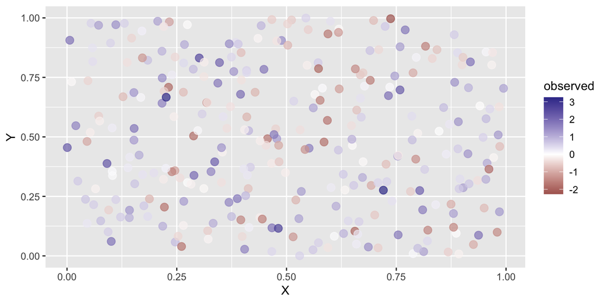

## Moderate observation errors

- \(\sigma_{obs}\) = \(\sigma_{O}\) = \(\sigma_{E}\)

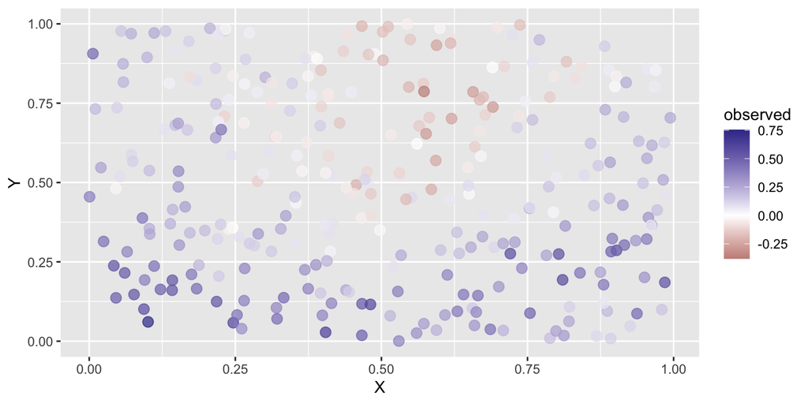

## Small observation errors

- \(\sigma_{obs}\) << \(\sigma_{O}\), \(\sigma_{E}\)

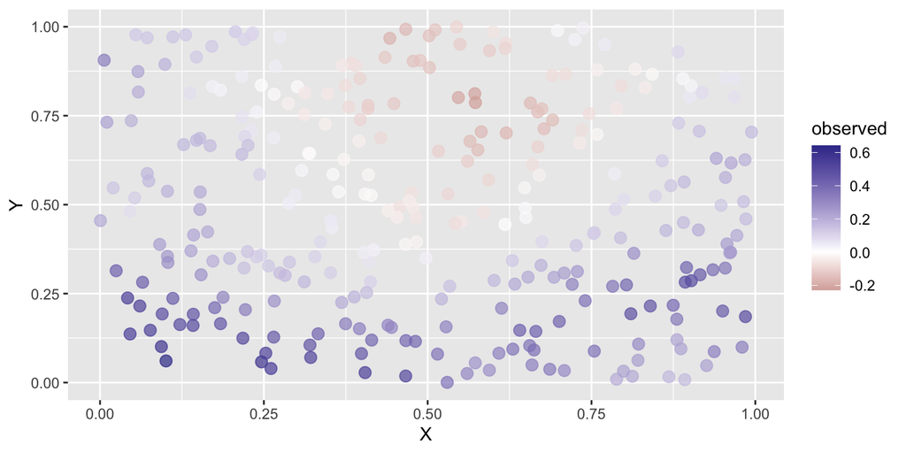

## Estimating random fields

- Georeferenced data often involve 1000s or more points
- Like in the 1-D setting, we need to approximate the spatial field
  - Options include nearest neighbor methods, covariance tapering, etc.
- sdmTMB uses an approach from INLA
  - for VAST users, this is the same
  - INLA books:  
    https://www.r-inla.org/learnmore/books

## Introducing meshes

Implementing the SPDE with INLA requires constructing a ‘mesh’

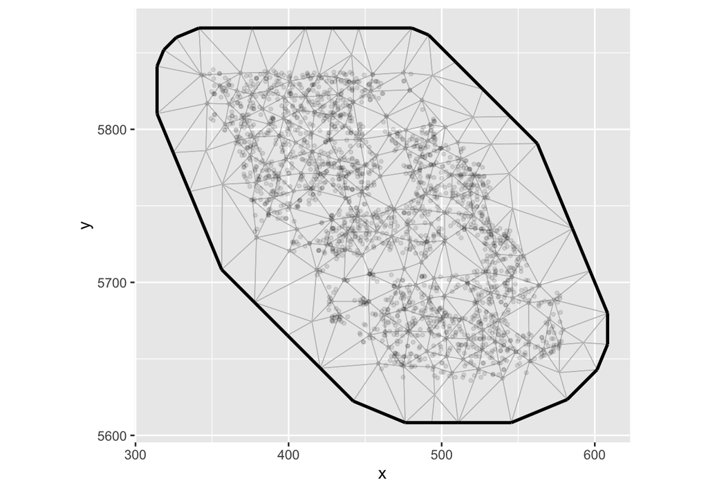

## Mesh construction

- A unique mesh is generally made for each dataset
- Rules of thumb:
  - More triangles = more computation time
  - More triangles = more fine-scale spatial predictions
  - Borders with coarser resolution reduce number of triangles
  - Use minimum edge size to avoid meshes becoming too fine
  - Want fewer vertices than data points
  - Triangle edge size needs to be smaller than spatial range
- “How to make a bad mesh?” [Haakon Bakka’s book](https://haakonbakkagit.github.io/btopic114.html)

## Building your own mesh

- `INLA::inla.mesh.2d()`: lets many arguments be customized
- `INLA::meshbuilder()`: Shiny app for constructing a mesh, provides R code
- Meshes can include barriers / islands / coastlines with shapefiles
- INLA books https://www.r-inla.org/learnmore/books

## Simplifying mesh construction in sdmTMB

sdmTMB has a function `make_mesh()` to quickly construct a basic mesh

Details in next set of slides

## Example: cutoff = 50km

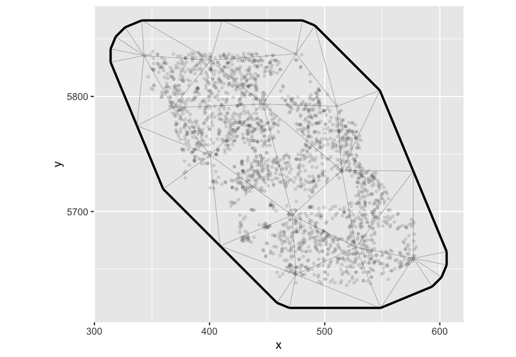

## Example: cutoff = 25km

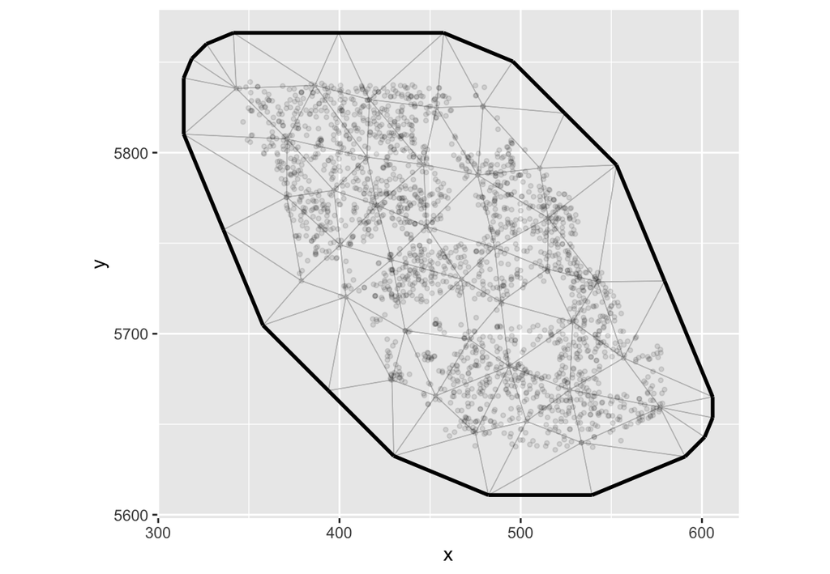

## Example: cutoff = 10km

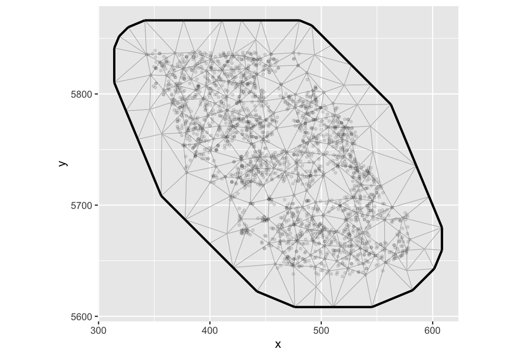

## sdmTMB highlights

sdmTMB is a user-friendly R package for modeling spatial processes

- Familiar syntax to widely used functions/packages; `glm()`, mgcv, glmmTMB, etc.
- Performs fast (marginal) maximum likelihood estimation via TMB
- Widely applicable to species distribution modelling, stock assessment inputs, bycatch models, etc. that include spatially referenced data

## General sdmTMB workflow

1. Prepare data (convert to UTMs, scale covariates, …)
2. Construct a mesh
3. Fit the model
4. Inspect the model (and possibly refit the model)
5. Predict from the model
6. Calculate any derived quantities

## General sdmTMB workflow

1. Prepare data: `add_utm_columns()`
2. Construct a mesh: `make_mesh()`
3. Fit the model: `sdmTMB()`
4. Inspect the model: `print()`, `sanity()`, `tidy()`, `residuals()`
5. Predict from the model: `predict()`
6. Get derived quantities: `get_index()`, `get_cog()`, `get_eao()`

## Preparing the data

Prepare the data in wide format (i.e. row = observation)

Make sure there is no **NA** in the used covariates

**NA** in the response value is OK (internally checked)

## Preparing the “space”: the use of UTMs

Need a projection that preserves constant distance

UTMs work well for regional analyses

Helper function: `sdmTMB::add_utm_columns()`

Internally, guesses at UTM zone and uses the sf package:  
`sf::st_as_sf()`, `sf::st_transform()`, and `sf::st_coordinates()`

Or use the sf or sp packages yourself

## Example of adding UTM columns

```r
d <- data.frame(
  lat = c(52.1, 53.4),
  lon = c(-130.0, -131.4)
)
d <- sdmTMB::add_utm_columns(d, c("lon", "lat"))
```

```
## Detected UTM zone 9N; CRS = 32609.
```

```
## Visit https://epsg.io/32609 to verify.
```

```r
d
```

[output not shown]

- Note default `units = "km"`
- Why? Range parameter estimated in units of X and Y
- Should be not too big or small for estimation

## Constructing a mesh

`make_mesh()` has 2 shortcuts to mesh construction

1. K-means algorithm: used to cluster points (e.g., `n_knots = 100`); approach taken in VAST; sensitive to random `seed` argument!
2. Cutoff: minimum allowed distance between vertices (e.g., `cutoff = 10`) - *the preferred option*

Alternatively, build any INLA mesh and supply it to the `mesh` argument in `make_mesh()`

## Constructing a mesh

Size of mesh has the single largest impact on fitting speed

`cutoff` is in units of x and y (minimum triangle size)

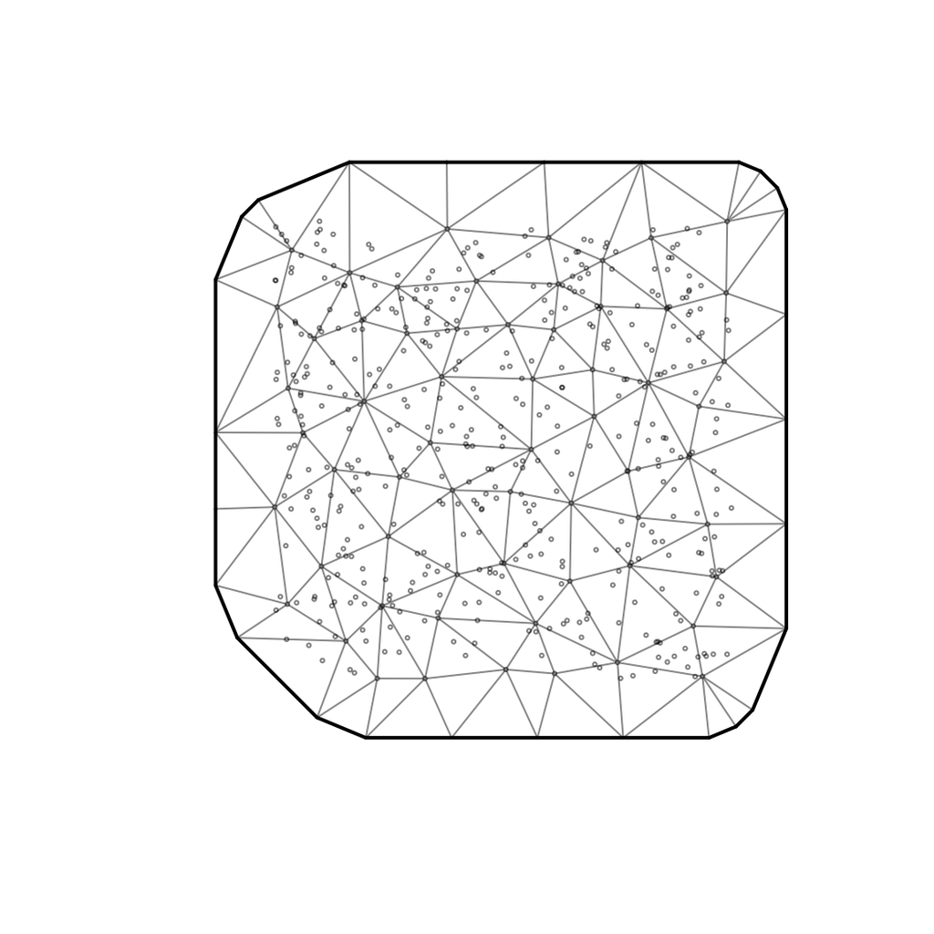

```r
d <- data.frame(x = runif(500), y = runif(500))
mesh <- make_mesh(d, xy_cols = c("x", "y"), cutoff = 0.1)
mesh$mesh$n
plot(mesh)
```

## Fitting the model: sdmTMB()

Set up is similar to `glmmTMB()`. Common arguments:

```r
fit <- sdmTMB(
  formula,
  data,
  mesh,
  time = NULL,
  family = gaussian(link = "identity"),
  spatial = c("on", "off"),
  spatiotemporal = c("iid", "ar1", "rw", "off"),
  silent = TRUE,
  ...
)
```

See `?sdmTMB`

## Formula interface

sdmTMB uses a similar formula interface to widely used R packages

A formula is used to specify fixed effects and (optionally) random intercepts

```r
# linear effect of x1:
formula = y ~ x1

# add smoother effect of x2:
formula = y ~ x1 + s(x2)

# add random intercept by group g:
formula = y ~ x1 + s(x2) + (1 | g)
```

## Smoothers (as in mgcv)

```r
# smoother effect of x:
formula = y ~ s(x)

# basis dimension of 5:
formula = y ~ s(x, k = 5)

# bivariate smoother effect of x & y:
formula = y ~ s(x, y)

# smoother effect of x1 varying by x2:
formula = y ~ s(x1, by = x2)

# other kinds of mgcv smoothers:
formula = ~ s(month, bs = "cc", k = 12)
```

Smoothers are penalized (‘p-splines’), i.e. data determine ‘wiggliness’

## Other common R formula options

Polynomials and omitting the intercept:

```r
# transformations using `I()` notation
y ~ depth + I(depth^2)

# polynomial functions using `poly`
y ~ poly(depth, degree = 2)

# omit intercept
y ~ -1 + as.factor(year)
y ~ 0 + as.factor(year)
```

## Syntax: families and links

Many of the same families used in `glm()`, `glmmTMB()`, `mgcv::gam()` can be used here

Includes: `gaussian()`, `Gamma()`, `binomial()`, `poisson()`, `Beta()`, `student()`, `tweedie()`, `nbinom1()`, `nbinom2()`, `truncated_nbinom1()`, `truncated_nbinom2()`, `delta_gamma()`, `delta_lognormal()`, `delta_beta()`, and more…

All have `link` arguments

See `?sdmTMB::Families`

## An aside on the Tweedie

Useful for positive continuous data with zeros (e.g., biomass density per unit effort)

Dispersion ( \(\phi\) ) and power ( \(p\) ) parameters allow for a wide variety of shapes including many zeros

Also known as compound Poisson-Gamma distribution

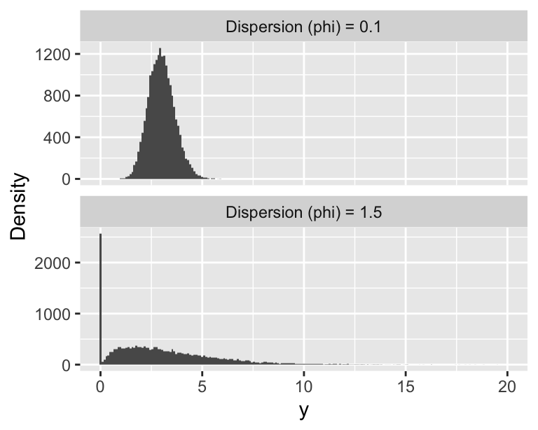

## An aside on the student-t

Useful for continuous data with extreme values.

Can also be used to deal with positive data when using *log* `link`

`df` parameters controls for the amount of tail in the distribution i.e. degree of “extreme” values

P.S: beware when df << 3. All noise is assimilated in the “observation error”

## An aside on delta models

- Delta/hurdle model has 2 sub-models:
- presence/absence (binomial, logit link)
- positive model (link varies by family)
- `family` argument to sdmTMB can be a list()
- for convenience, many delta- families implemented: `delta_gamma`, `delta_lognormal`, `delta_truncated_nbinom2` etc

## Spatial vs. spatiotemporal fields - notion

- A spatial field can be thought of as a spatial intercept
  - a wiggly spatial process that is constant in time. e.g. areas that has on average a higher/lower animal density, constant “hot/cold-spot”
- Spatiotemporal variation represents separate fields estimated for each time slice (possibly correlated)
  - wiggly spatial processes that change through time. e.g. inter-annual variability in “hot/cold-spot” locations

## Spatial fields can be turned on/off

- By default `sdmTMB()` estimates a spatial field

```r
fit <- sdmTMB(
  y ~ x,
  family = gaussian(),
  data = dat,
  mesh = mesh,
  spatial = "on", #<<
  ...
)
```

## Extracting spatial variance and range

```r
mesh <- make_mesh(pcod_2011, c("X", "Y"), cutoff = 20)
fit <- sdmTMB(
  density ~ s(depth),
  data = pcod_2011, mesh = mesh,
  family = tweedie(link = "log")
)
```

## Extracting spatial variance and range

```r
print(tidy(fit, "ran_pars"))
```

```
## # A tibble: 4 × 5
##   term      estimate std.error conf.low conf.high
##   <chr>        <dbl>     <dbl>    <dbl>     <dbl>
## 1 range        16.8    13.7       3.40      83.3
## 2 phi          13.7     0.663    12.4       15.0
## 3 sigma_O       2.20    1.23      0.735      6.59
## 4 tweedie_p     1.58    0.0153    1.55       1.61
```

## Why *not* estimate a spatial field?

- If shared process across time slices isn’t of interest
- If magnitude of spatiotemporal variability >> spatial variation
- If confounded with other parameters (more later)

## Spatiotemporal fields can be turned on/off

- By default `sdmTMB()` estimates a spatiotemporal field if the `time` argument is specified

```r
fit <- sdmTMB(
  y ~ x,
  family = gaussian(),
  data = dat,
  mesh = mesh,
  time = "year", # column in `data` #<<
  spatiotemporal = "iid", #<<
  ...
)
```

## Types of spatiotemporal fields

- None (`spatiotemporal = "off"`)
- Independent (`spatiotemporal = "iid"`)
- Random walk (`spatiotemporal = "rw"`)
- Autoregressive (`spatiotemporal = "ar1"`)

## How spatiotemporal fields relate to MARSS models

- Random effects estimated at knot locations
- IID = independent by year (no time series)
- RW = \[x_{t} = x{t-1} + \epsilon_{t}\]
- AR = \[x_{t} = b \cdot x{t-1} + \epsilon_{t}\]

## Independent (IID) spatiotemporal fields

- Useful if pattern changes much between years

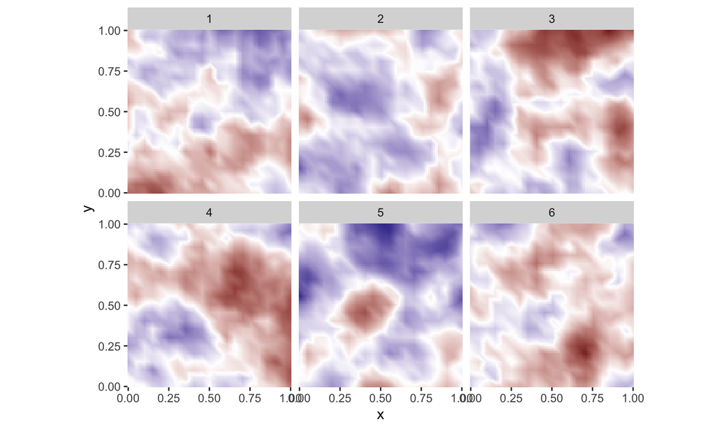

## AR1 spatiotemporal fields

- Useful if pattern are related between years.  
  P.S: Random walk = AR1 with 1.0 correlation

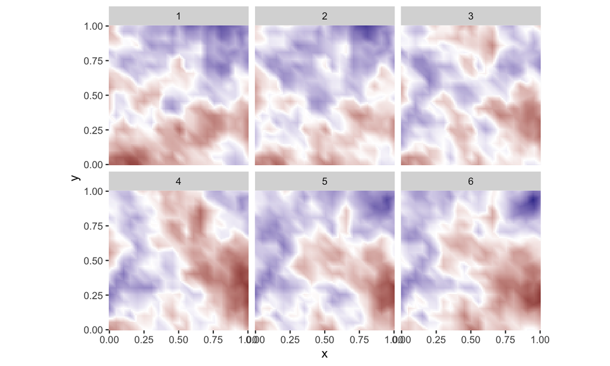

## Spatiotemporal fields

- Why include spatiotemporal fields?
  - If the data are collected in both space and time *and* there are ‘latent’ spatial processes that vary through time
  - E.g., effect of water temperature on abundance if temperature wasn’t in the model
  - Represents all the missing variables that vary through time
  - Why would a field be IID vs RW/AR1?
  - Do we expect hotspots to be independent with each time slice or adapt slowly over time?

## Time - varying coefficients

- Specify these with the `time_varying` formula
- `time_varying_type` controls structure (“rw”, “ar1”, etc)
- Covariates shouldn’t be in both `time_varying` and main formulas
- Intercept included implicitly, but can be turned off with `-1` or `0`

## Time - varying coefficients

Example: time varying intercept

```r
fit <- sdmTMB(
  y ~ 0, # global intercept off
  time_varying = ~ 1,
  time_varying_type = "rw",
  family = gaussian(),
  time = "year", # column in `data` #<<
  spatiotemporal = "iid", #<<
  ...
)
```

## Time - varying coefficients

Example: time varying intercept and slope

```r
fit <- sdmTMB(
  y ~ 0, # global intercept off
  time_varying = ~ x,
  time_varying_type = "rw",
  family = gaussian(),
  time = "year", # column in `data` #<<
  spatiotemporal = "iid", #<<
  ...
)
```

## Time - varying coefficients

Example: time varying slope

```r
fit <- sdmTMB(
  y ~ 1, # global intercept on
  time_varying = ~ 0 + x,
  time_varying_type = "rw",
  family = gaussian(),
  time = "year", # column in `data` #<<
  spatiotemporal = "iid", #<<
  ...
)
```

## Spatially - varying coefficients

- Environmental processes may have different impacts across a large region
- `spatial_varying` allows separate fields to be estimated for each coefficient
- Unlike time-varying we do want the effect in both the main and `spatial_varying` formulas

## Spatially - varying coefficients

```r
fit <- sdmTMB(
  y ~ x,
  spatial_varying = ~ 0 + x,
  family = gaussian(),
  time = "year", # column in `data` #<<
  spatiotemporal = "iid", #<<
  ...
)
```

## Spatially - varying coefficients

- Example via Philina English (DFO) for sdmTMB paper

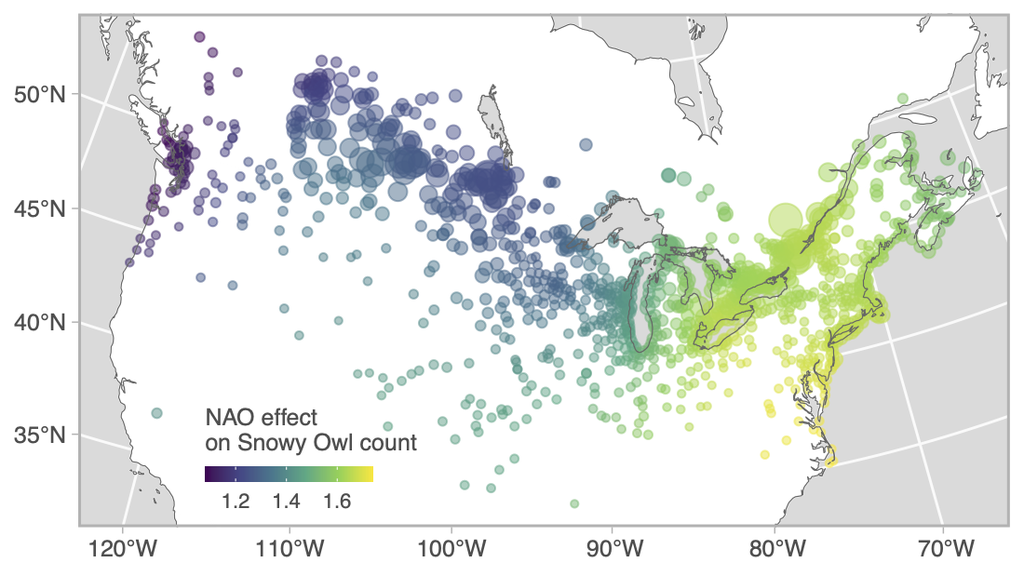

## After model fitting

Inspecting, summarizing, predicting, etc.

Covered in examples in next slides.

- `predict()`: `?predict.sdmTMB`
- `residuals()`: `?residuals.sdmTMB`
- `tidy()`: `?tidy.sdmTMB`
- `print()`
- `sanity()`
- `get_index()`
- `...`

## Examples of workflow / other functions

```r
data("pcod")
mesh <- make_mesh(pcod, c("X", "Y"), cutoff = 20)
pcod$fyear <- as.factor(pcod$year)

fit <- sdmTMB(
  density ~ fyear,
  time_varying = NULL,
  data = pcod,
  mesh = mesh,
  time = "year",
  spatiotemporal = "iid",
  family = tweedie(link = "log")
)
```

## Did the model converge?

```r
print(sanity(fit))
```

```
## $hessian_ok
## [1] TRUE
##
## $eigen_values_ok
## [1] TRUE
##
## $nlminb_ok
## [1] TRUE
##
## $range_ok
## [1] TRUE
##
## $gradients_ok
## [1] TRUE
##
## $se_magnitude_ok
## [1] TRUE
##
## $se_na_ok
## [1] TRUE
##
## $sigmas_ok
## [1] TRUE
##
## $all_ok
## [1] TRUE
```

## Diagnostics / residuals

- Similar to what we discussed for time series models
- Vignette for residual checking https://pbs-assess.github.io/sdmTMB/articles/residual-checking.html

## Generating an index of abundance

- First predict to some regular grid

```r
nd <- replicate_df(qcs_grid, "year", unique(pcod$year))
nd$fyear <- as.factor(nd$year)
predictions <- predict(fit,
               newdata = nd,
               return_tmb_object = TRUE)
```

## Call `get_index` to derive annual estimates

```r
indx <- get_index(predictions)
print(indx)
```

```
##   year       est       lwr      upr  log_est        se  type
## 1 2003 209277.01 151513.00 289063.4 12.25141 0.1647925 index
## 2 2004 316826.48 244648.36 410299.2 12.66611 0.1319067 index
## 3 2005 355482.15 274277.01 460729.7 12.78123 0.1323170 index
## 4 2007  91540.99  66923.25 125214.4 11.42454 0.1598195 index
## 5 2009 150187.87 109089.00 206770.6 11.91964 0.1631269 index
## 6 2011 274230.96 212808.46 353381.7 12.52173 0.1293790 index
## 7 2013 274541.65 204421.77 368713.8 12.52286 0.1504709 index
## 8 2015 326960.45 241466.23 442725.0 12.69759 0.1546506 index
## 9 2017 151502.44 110227.70 208232.5 11.92836 0.1622752 index
```